# Ex06_ZM

Author

Zoe Marolf

Published

October 24, 2024

## Setup

```r
library(ggplot2)
library(tidyr)
library(dplyr)
library(pheatmap)
```

## Comparison of Expression Estimates

*The data set consists of 3 normal samples and 3 treated samples with 2.5 Mio reads each. The reads are simulated to come from genes on the human chromosome 1.

The expression values from featureCounts were created with the library Rsubread to generate the counts.* From the SubreadUsersGuide: A feature is an interval (range of positions) on one of the reference sequences. A meta-feature is a set of features that represents a biological construct of interest. For example, features often correspond to exons and meta-features to genes. Features sharing the same feature identifier in the GTF or SAF annotation are taken to belong to the same meta-feature.

## Questions

### 1. Depending on the featureCount mode, how many alignments are ignored during counting?

countMultiMappingReads = FALSE does not count reads that map to more than one location in the reference genome. countMultiMappingReads = TRUE and fraction = TRUE counts each alignment fractionally, meaning each alignment gets 1/x of a count where x is the total number of alignments reported for the read.

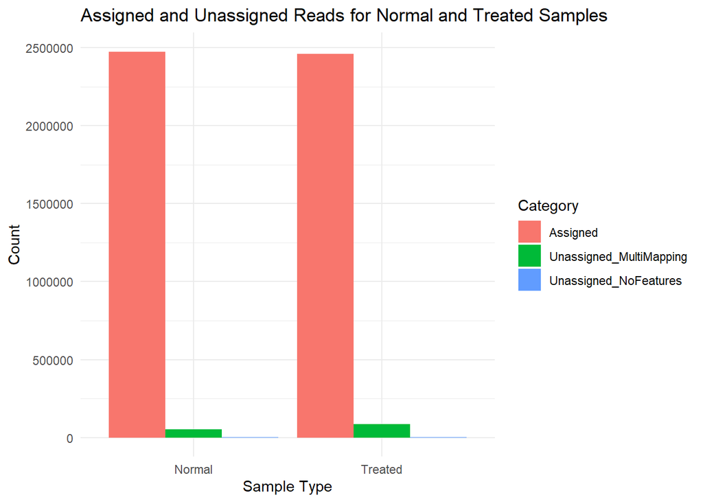

```r
countResult1 = readRDS("C:/Users/zoe/OneDrive - ETH Zurich/Documents/ETHZ/24HS_MSc/STA426/week6/countResult1.RDS")
countResult2 = readRDS("C:/Users/zoe/OneDrive - ETH Zurich/Documents/ETHZ/24HS_MSc/STA426/week6/countResult2.RDS")

res1 = countResult1[["stat"]]
res1 = res1[c(1,3,4),] # Assigned, Unassigned_MultiMapping, Unassigned_NoFeatures

res2 = countResult2[["stat"]]
res2 = res2[c(1,3,4),] # Assigned, Unassigned_MultiMapping, Unassigned_NoFeatures

# Assigned and unassigned reads for countMultiMappingReads = FALSE
res_combined = data.frame(res1[,1])
colnames(res_combined) = "Status"
res_combined$Normal = rowMeans(res1[,c(2,3,4)])
res_combined$Treated = rowMeans(res1[,c(5,6,7)])
res_long <- pivot_longer(res_combined,
                         cols = c("Normal", "Treated"),
                         names_to = "Sample_Type",
                         values_to = "Count")
ggplot(res_long, aes(x = Sample_Type, y = Count, fill = Status)) +
  geom_bar(stat = "identity", position = "dodge") +
  labs(x = "Sample Type", y = "Count", fill = "Category") +
  theme_minimal() +
  ggtitle("Assigned and Unassigned Reads for Normal and Treated Samples")
```

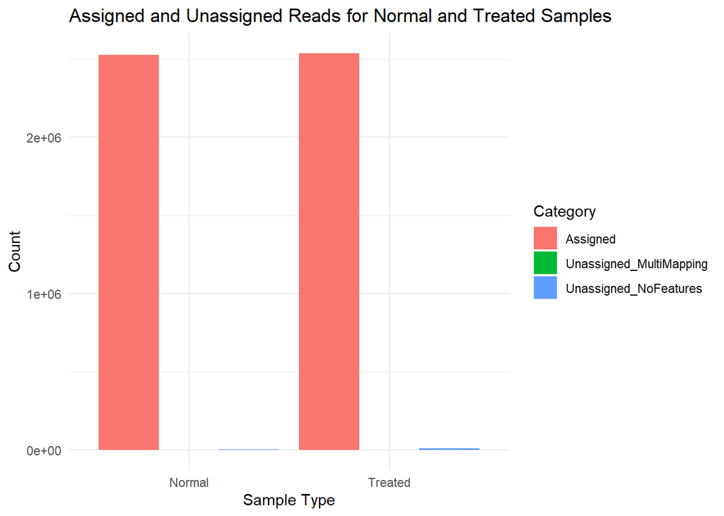

```r
# Assigned and unassigned reads for countMultiMappingReads = TRUE
res_combined2 = data.frame(res2[,1])
colnames(res_combined2) = "Status"
res_combined2$Normal = rowMeans(res2[,c(2,3,4)])
res_combined2$Treated = rowMeans(res2[,c(5,6,7)])
res_long2 <- pivot_longer(res_combined2,
                         cols = c("Normal", "Treated"),
                         names_to = "Sample_Type",
                         values_to = "Count")
ggplot(res_long2, aes(x = Sample_Type, y = Count, fill = Status)) +
  geom_bar(stat = "identity", position = "dodge") +
  labs(x = "Sample Type", y = "Count", fill = "Category") +
  theme_minimal() +
  ggtitle("Assigned and Unassigned Reads for Normal and Treated Samples")
```

When Multimapped reads are ignored, 53’600 (N) and 86’050 (T) are ignored while in both cases only ca 150 are left unassigned because they did not map to any feature. When Multimapped reads are considered, 3550 (N) and 8300 (T) reads are unassigned.

### 2. Compare the counts from featureCounts with the genelevel counts from RSEM. Which genes have different values?

### 3. How does the sum of the counts in RSEM compare to the number of the aligned reads?

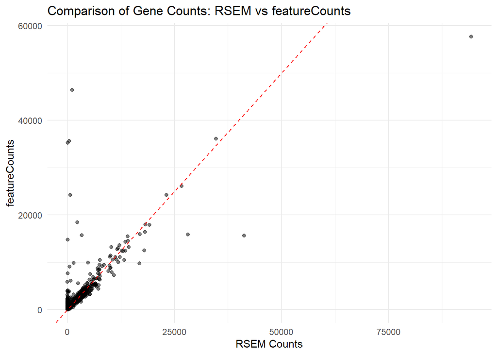

```r
# read in RSEM files (only normal for now)
rsem_data_n1 <- read.table("RSEM_counts/N1.genes.results", header = TRUE, sep = "\t")
rsem_data_n2 <- read.table("RSEM_counts/N2.genes.results", header = TRUE, sep = "\t")
rsem_data_n3 <- read.table("RSEM_counts/N3.genes.results", header = TRUE, sep = "\t")

rsem_counts <- data.frame(gene_id = rsem_data_n1$gene_id, RSEM_counts_n1 = rsem_data_n1$expected_count)
rsem_counts$RSEM_counts_n2 <- rsem_data_n2$expected_count
rsem_counts$RSEM_counts_n3 <- rsem_data_n3$expected_count
rsem_counts$RSEM_counts_avg <- rowMeans(rsem_counts[,c(2,3,4)])

# extract featureCounts counts
feature_counts = countResult1$counts
feature_counts <- data.frame(gene_id = rownames(feature_counts), featureCounts_avg1 = rowMeans(feature_counts[,c(2,3,4)]))
feature_counts$featureCounts_avg2 = rowMeans(countResult2$counts[,c(1,2,3)])

# compare
merged_counts <- merge(rsem_counts[,c(1,5)], feature_counts, by = "gene_id")
merged_counts$Difference1 <- abs(merged_counts$RSEM_counts_avg - merged_counts$featureCounts_avg1)
merged_counts$Difference2 <- abs(merged_counts$RSEM_counts_avg - merged_counts$featureCounts_avg2)

# genes that differ
significant_genes_diff1 <- merged_counts[merged_counts$Difference1 > 100, ]
significant_genes_diff2 <- merged_counts[merged_counts$Difference2 > 100, ]

# visualize
ggplot(merged_counts, aes(x = RSEM_counts_avg, y = featureCounts_avg1)) +
  geom_point(alpha = 0.5) +
  geom_abline(slope = 1, intercept = 0, color = "red", linetype = "dashed") +  # Line of perfect agreement
  labs(x = "RSEM Counts", y = "featureCounts", title = "Comparison of Gene Counts: RSEM vs featureCounts") +
  theme_minimal()
```

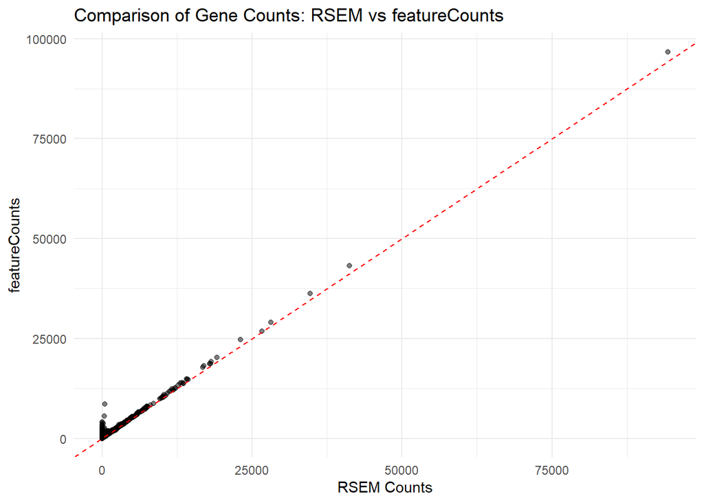

```r
ggplot(merged_counts, aes(x = RSEM_counts_avg, y = featureCounts_avg2)) +
  geom_point(alpha = 0.5) +
  geom_abline(slope = 1, intercept = 0, color = "red", linetype = "dashed") +  # Line of perfect agreement
  labs(x = "RSEM Counts", y = "featureCounts", title = "Comparison of Gene Counts: RSEM vs featureCounts") +
  theme_minimal()
```

The genes that differ can be found in the data frame significant_genes_diff1 (w/o multimapping) and significant_genes_diff2 (w multimapping).

The RSEM counts are similar to the featureCounts counts when allowing multimapping. Without multimapping in featureCounts, the number of alignments is lower than RSEM’s sum. (Considering only normal samples)

### 4. Compute pair-wise correlation of the samples based on the isoform counts and gene level counts

For the isoform counts…

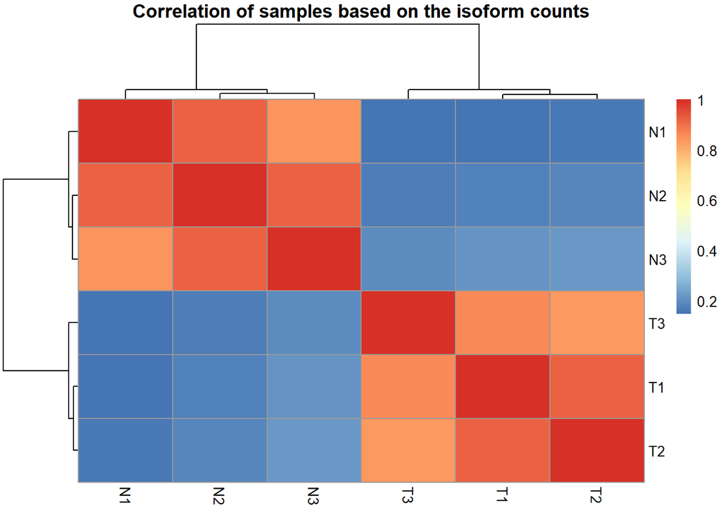

```r
# load data (RSEM isoforms)
RSEM_N1_isoforms <- read.table("RSEM_counts/N1.isoforms.results", header=TRUE, sep="\t")
RSEM_N2_isoforms <- read.table("RSEM_counts/N2.isoforms.results", header=TRUE, sep="\t")
RSEM_N3_isoforms <- read.table("RSEM_counts/N3.isoforms.results", header=TRUE, sep="\t")

RSEM_T1_isoforms <- read.table("RSEM_counts/T1.isoforms.results", header=TRUE, sep="\t")
RSEM_T2_isoforms <- read.table("RSEM_counts/T2.isoforms.results", header=TRUE, sep="\t")
RSEM_T3_isoforms <- read.table("RSEM_counts/T3.isoforms.results", header=TRUE, sep="\t")

RSEM_isoforms_list = list(RSEM_N1_isoforms, RSEM_N2_isoforms, RSEM_N3_isoforms, RSEM_T1_isoforms, RSEM_T2_isoforms, RSEM_T3_isoforms)

# create count matrix for isoforms
expected_counts_list_isoforms <- lapply(RSEM_isoforms_list, function(count_df) {
  return(count_df$expected_count)
})
RSEM_counts_isoforms <- do.call(cbind, expected_counts_list_isoforms)
RSEM_counts_isoforms = cbind(RSEM_N1_isoforms$gene_id, RSEM_counts_isoforms)
colnames(RSEM_counts_isoforms) <- c("gene_id", "N1", "N2", "N3", "T1", "T2", "T3")
rownames(RSEM_counts_isoforms) = RSEM_N1_isoforms$transcript_id

# pair-wise correlations
RSEM_counts_isoforms = RSEM_counts_isoforms %>% as.data.frame() %>% mutate(across(2:7, ~as.numeric(.)))

isoform_correlation <- cor(RSEM_counts_isoforms[,2:7], method="pearson")
pheatmap(isoform_correlation, fontsize = 10,  main = "Correlation of samples based on the isoform counts")
```

Now for the gene counts…

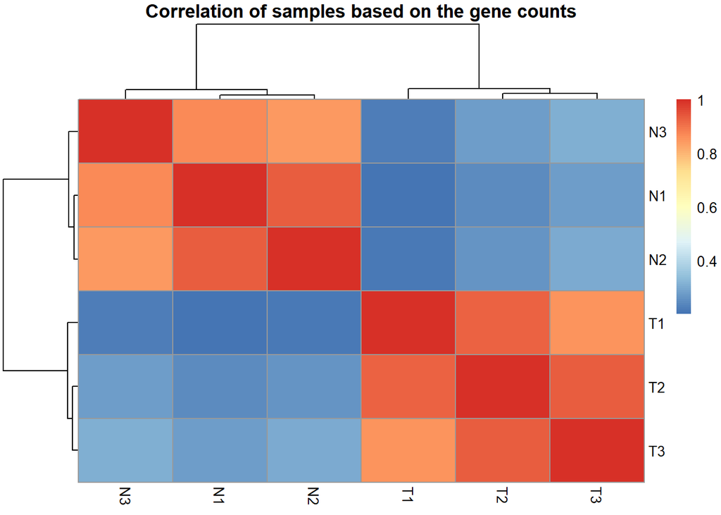

```r
# read in RSEM files (also treated now)
rsem_data_t1 <- read.table("RSEM_counts/T1.genes.results", header = TRUE, sep = "\t")
rsem_data_t2 <- read.table("RSEM_counts/T2.genes.results", header = TRUE, sep = "\t")
rsem_data_t3 <- read.table("RSEM_counts/T3.genes.results", header = TRUE, sep = "\t")

RSEM_genes_list = list(rsem_data_t1, rsem_data_t2, rsem_data_t3, rsem_data_n1, rsem_data_n2, rsem_data_n3)

expected_counts_list_genes <- lapply(RSEM_genes_list, function(count_df) {
  return(count_df$expected_count)
})
RSEM_counts_genes <- do.call(cbind, expected_counts_list_genes)
colnames(RSEM_counts_genes) <- c("N1", "N2", "N3", "T1", "T2", "T3")
rownames(RSEM_counts_genes) = rsem_data_n1$gene_id

gene_correlation <- cor(RSEM_counts_genes, method="pearson")
pheatmap(gene_correlation, fontsize = 10, main = "Correlation of samples based on the gene counts")
```

Clearly, samples of the same condition correlate strongly whereas samples of different conditions do not. It also seems that when considering isoform counts, the correlations are more pronounced (more dark red and dark blue than in the heatmap with the gene counts). This might be due to condition-specific isoform expression which results in an increased contrast in the heatmap. On the other hand gene-level counts average out condition-specific effects which makes the heatmap a little more homogenous.